# Bike Sharing

## Exploratory Data Analysis (EDA) and Visualization

**By**: *Victor Cornejo*

## Introduction

Bike sharing systems are a new generation of traditional bike rentals where the process of signing up, renting and returning is automated. Through these systems, users are able to easily rent a bike from one location and return them to another. I analyzed bike sharing data from Washington D.C.

In this project, I performed tasks to clean, visualize, and explore the bike sharing data. I also investigated open-ended questions. These open-ended questions asked me to think critically about how the plots I created to provide insights into the data.

In this project I practiced:

- reading plaintext delimited data into `pandas`
- wrangling data for analysis
- using EDA to learn about your data
- making informative plots

```python
import seaborn as sns
import csv
import numpy as np
import pandas as pd
import matplotlib.pyplot as plt
import zipfile
from pathlib import Path
import ds100_utils

# Default plot configurations
%matplotlib inline
plt.rcParams['figure.figsize'] = (16,8)
plt.rcParams['figure.dpi'] = 150
sns.set()

import warnings
warnings.filterwarnings("ignore")

from IPython.display import display, Latex, Markdown
```

## Loading Bike Sharing Data

The data I explored was collected from a bike sharing system in Washington D.C.

The variables in this data frame were defined as:

| Variable | Description |
| --- | --- |
| instant | record index |
| dteday | date |
| season | 1. spring 2. summer 3. fall 4. winter |
| yr | year (0: 2011, 1:2012) |
| mnth | month ( 1 to 12) |
| hr | hour (0 to 23) |
| holiday | whether day is holiday or not |
| weekday | day of the week |
| workingday | if day is neither weekend nor holiday |
| weathersit | 1. clear or partly cloudy 2. mist and clouds 3. light snow or rain 4. heavy rain or snow |
| temp | normalized temperature in Celsius (divided by 41) |
| atemp | normalized "feels-like" temperature in Celsius (divided by 50) |
| hum | normalized percent humidity (divided by 100) |
| windspeed | normalized wind speed (divided by 67) |
| casual | count of casual users |
| registered | count of registered users |
| cnt | count of total rental bikes including casual and registered |

### Downloading the Data

```python
data_url = 'https://github.com/DS-100/fa20/raw/gh-pages/resources/assets/datasets/hw3-bikeshare.zip'
file_name = 'data.zip'
data_dir = '.'

dest_path = ds100_utils.fetch_and_cache(data_url=data_url, data_dir=data_dir, file=file_name)
print('Saved at {}'.format(dest_path))

zipped_data = zipfile.ZipFile(dest_path, 'r')

data_dir = Path('data')
zipped_data.extractall(data_dir)


print("Extracted Files:")
for f in data_dir.glob("*"):
    print("\t",f)
```

```
Using version already downloaded: Sun Dec 18 17:39:38 2022
MD5 hash of file: 2bcd2ca89278a8230f4e9461455c0811
Saved at data.zip
Extracted Files:
	 data/bikeshare.txt
```

### Examining the file contents

```python
for line in ds100_utils.head(data_dir/'bikeshare.txt'):
    print(line,end="")
```

```
instant,dteday,season,yr,mnth,hr,holiday,weekday,workingday,weathersit,temp,atemp,hum,windspeed,casual,registered,cnt
1,2011-01-01,1,0,1,0,0,6,0,1,0.24,0.2879,0.81,0,3,13,16
2,2011-01-01,1,0,1,1,0,6,0,1,0.22,0.2727,0.8,0,8,32,40
3,2011-01-01,1,0,1,2,0,6,0,1,0.22,0.2727,0.8,0,5,27,32
4,2011-01-01,1,0,1,3,0,6,0,1,0.24,0.2879,0.75,0,3,10,13
```

### Size

```python
print("Size:", (data_dir/"bikeshare.txt").stat().st_size, "bytes")
print("Line Count:", ds100_utils.line_count(data_dir/"bikeshare.txt"), "lines")
```

```
Size: 1156736 bytes
Line Count: 17380 lines
```

### Loading the data

The following code loaded the data into a Pandas DataFrame.

```python
bike = pd.read_csv(data_dir/'bikeshare.txt')
bike.head()
```

|  | instant | dteday | season | yr | mnth | hr | holiday | weekday | workingday | weathersit | temp | atemp | hum | windspeed | casual | registered | cnt |
| --- | --- | --- | --- | --- | --- | --- | --- | --- | --- | --- | --- | --- | --- | --- | --- | --- | --- |
| 0 | 1 | 2011-01-01 | 1 | 0 | 1 | 0 | 0 | 6 | 0 | 1 | 0.24 | 0.2879 | 0.81 | 0.0 | 3 | 13 | 16 |
| 1 | 2 | 2011-01-01 | 1 | 0 | 1 | 1 | 0 | 6 | 0 | 1 | 0.22 | 0.2727 | 0.80 | 0.0 | 8 | 32 | 40 |
| 2 | 3 | 2011-01-01 | 1 | 0 | 1 | 2 | 0 | 6 | 0 | 1 | 0.22 | 0.2727 | 0.80 | 0.0 | 5 | 27 | 32 |
| 3 | 4 | 2011-01-01 | 1 | 0 | 1 | 3 | 0 | 6 | 0 | 1 | 0.24 | 0.2879 | 0.75 | 0.0 | 3 | 10 | 13 |
| 4 | 5 | 2011-01-01 | 1 | 0 | 1 | 4 | 0 | 6 | 0 | 1 | 0.24 | 0.2879 | 0.75 | 0.0 | 0 | 1 | 1 |

Below, I show the shape of the file. I could see that the size of the DataFrame matches the number of lines in the file, minus the header row.

```python
bike.shape
```

```
(17379, 17)
```

## Examining the Data

```python
bike.head(3)
```

|  | instant | dteday | season | yr | mnth | hr | holiday | weekday | workingday | weathersit | temp | atemp | hum | windspeed | casual | registered | cnt |
| --- | --- | --- | --- | --- | --- | --- | --- | --- | --- | --- | --- | --- | --- | --- | --- | --- | --- |
| 0 | 1 | 2011-01-01 | 1 | 0 | 1 | 0 | 0 | 6 | 0 | 1 | 0.24 | 0.2879 | 0.81 | 0.0 | 3 | 13 | 16 |
| 1 | 2 | 2011-01-01 | 1 | 0 | 1 | 1 | 0 | 6 | 0 | 1 | 0.22 | 0.2727 | 0.80 | 0.0 | 8 | 32 | 40 |
| 2 | 3 | 2011-01-01 | 1 | 0 | 1 | 2 | 0 | 6 | 0 | 1 | 0.22 | 0.2727 | 0.80 | 0.0 | 5 | 27 | 32 |

Some limitations of this dataset are that this sample is only representative of a specific bikesharing company, at a specific location. Another two variables that could be analyzed would be the approximate distance each bike ride takes, and from this also compute the approximate speed by the times in which the ride began and ended.

## Data Preparation

A few of the variables that are numeric/integer actually encode categorical data. These include `holiday`, `weekday`, `workingday`, and `weathersit`. In the following sectipn, I converted these four variables to strings specifying the categories. In particular, using 3-letter labels (`Sun`, `Mon`, `Tue`, `Wed`, `Thu`, `Fri`, and `Sat`) for `weekday`. I simply used `yes`/`no` for `holiday` and `workingday`.

#### (Decoding `weekday`, `workingday`, and `weathersit`)

Decoding the `holiday`, `weekday`, `workingday`, and `weathersit` fields:

1. `holiday`: Converted to `yes` and `no`.
2. `weekday`: It turns out that Monday is the day with the most holidays. Mutated the `'weekday'` column to use the 3-letter label (`'Sun'`, `'Mon'`, `'Tue'`, `'Wed'`, `'Thu'`, `'Fri'`, and `'Sat'` ...) instead of its current numerical values. I assumed `0` would correspond to `Sun`, `1` to `Mon` and so on, in order of the previous sentence.
3. `workingday`: Converted to `yes` and `no`.
4. `weathersit`: I replaced each value with one of `Clear`, `Mist`, `Light`, or `Heavy`. Assuming `1` would correspond to `Clear`, `2` to `Mist`, and so on in order of the previous sentence.

```python
factor_dict = {
    'holiday': {0: 'no', 1: 'yes'},
    'weekday': {0: 'Sun', 1: 'Mon', 2: 'Tue', 3: 'Wed', 4: 'Thu', 5: 'Fri', 6: 'Sat'},
    'workingday': {0: 'no', 1: 'yes'},
    'weathersit': {1: 'Clear', 2: 'Mist', 3: 'Light', 4: 'Heavy'}
    }

bike.replace(factor_dict, inplace=True)
bike.head()
```

|  | instant | dteday | season | yr | mnth | hr | holiday | weekday | workingday | weathersit | temp | atemp | hum | windspeed | casual | registered | cnt |
| --- | --- | --- | --- | --- | --- | --- | --- | --- | --- | --- | --- | --- | --- | --- | --- | --- | --- |
| 0 | 1 | 2011-01-01 | 1 | 0 | 1 | 0 | no | Sat | no | Clear | 0.24 | 0.2879 | 0.81 | 0.0 | 3 | 13 | 16 |
| 1 | 2 | 2011-01-01 | 1 | 0 | 1 | 1 | no | Sat | no | Clear | 0.22 | 0.2727 | 0.80 | 0.0 | 8 | 32 | 40 |
| 2 | 3 | 2011-01-01 | 1 | 0 | 1 | 2 | no | Sat | no | Clear | 0.22 | 0.2727 | 0.80 | 0.0 | 5 | 27 | 32 |
| 3 | 4 | 2011-01-01 | 1 | 0 | 1 | 3 | no | Sat | no | Clear | 0.24 | 0.2879 | 0.75 | 0.0 | 3 | 10 | 13 |
| 4 | 5 | 2011-01-01 | 1 | 0 | 1 | 4 | no | Sat | no | Clear | 0.24 | 0.2879 | 0.75 | 0.0 | 0 | 1 | 1 |

#### (Holidays)

finding how many entries in the data correspond to holidays:

```python
num_holidays = bike['holiday'].value_counts()[1]
num_holidays
```

```
500
```

#### (Computing Daily Total Counts)

In the next few sections I analyzed the daily number of registered and unregistered users.

Constructing a data frame named `daily_counts` indexed by `dteday` with the following columns:

- `casual`: total number of casual riders for each day
- `registered`: total number of registered riders for each day
- `workingday`: whether that day is a working day or not (`yes` or `no`)

```python
daily_counts = bike.groupby('dteday').agg({'casual': 'sum', 'registered': 'sum', 'workingday': 'first'})
daily_counts.head()
```

| dteday | casual | registered | workingday |
| --- | --- | --- | --- |
| 2011-01-01 | 331 | 654 | no |
| 2011-01-02 | 131 | 670 | no |
| 2011-01-03 | 120 | 1229 | yes |
| 2011-01-04 | 108 | 1454 | yes |
| 2011-01-05 | 82 | 1518 | yes |

## Exploring the Distribution of Riders

I began by comparing the distribution of the daily counts of casual and registered riders.

### Matplotlib and Seaborn Table of Common Functions

`x` and `y` are sequences of values (i.e. arrays, lists, or Series).

| Function | Description |
| --- | --- |
| `plt.plot(x, y)` | Creates a line plot of `x` against `y` |
| `plt.title(name)` | Adds a title `name` to the current plot |
| `plt.xlabel(name)` | Adds a label `name` to the x-axis |
| `plt.ylabel(name)` | Adds a label `name` to the y-axis |
| `plt.scatter(x, y)` | Creates a scatter plot of `x` against `y` |
| `plt.hist(x, bins=None)` | Creates a histogram of `x`; `bins` can be an integer or a sequence |
| `plt.bar(x, height)` | Creates a bar plot of categories `x` and corresponding heights `height` |
| `sns.histplot(data, x, y, hue, kde)` | Creates a distribution plot; `data` is a DataFrame; `x`, `y` are column names in `data` that specify positions on the x and y axes; `hue` is a column name in `data` that adds subcategories to the plot… |
| `sns.lineplot(data, x, y, hue)` | Creates a line plot |
| `sns.scatterplot(data, x, y, hue, size)` | Creates a scatter plot; `size` is a vector that contains the size of point for each subcategory based on `hue` |
| `sns.kdeplot(x, y)` | Creates a kernel density estimate plot; `x`, `y` are series of data that indicate positions on the `x` and `y` axis |
| `sns.jointplot(x, y, data, kind)` | Creates a joint plot of 2 variables with KDE plot in the middle and a distribution plot for each variable on the sides; `kind` determines the visualization type for the distribution plot, can be `scat… |

Using the [`sns.histplot`](https://seaborn.pydata.org/generated/seaborn.histplot.html#seaborn.histplot) function I created a plot that overlayed the distribution of the daily counts of bike users, using blue to represent `casual` riders, and green to represent `registered` riders. The temporal granularity of the records was daily counts.

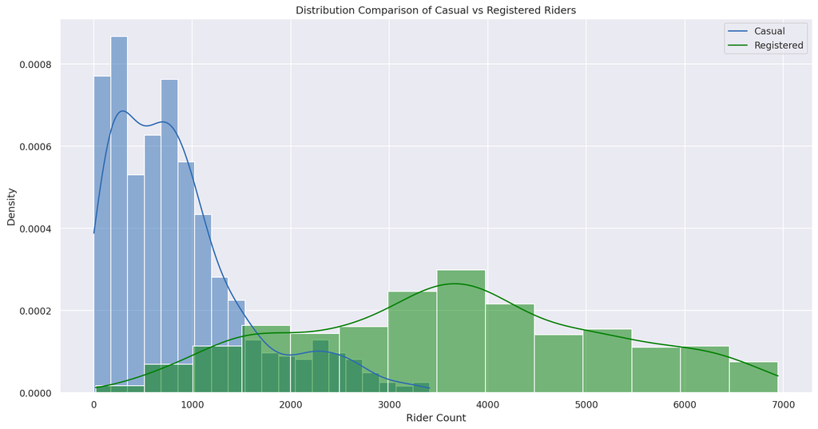

```python
sns.histplot(data=daily_counts, x='casual', color='#2d6bb3', stat='density', kde=True)
sns.histplot(data=daily_counts, x='registered', color='green', stat='density', kde=True)
plt.xlabel('Rider Count')
plt.ylabel('Density')
plt.title('Distribution Comparison of Casual vs Registered Riders')
plt.legend(['Casual', 'Registered'])
```

As seen, the distribution of the registered users seems to be normal, symetrical. Whereas the casual riders distribution is bimodal and skewed to the right. I bleive this to be because registered users ride usually throghout the days, whereas casual riders could have a spike on the weekends and festive days.

### However...

The density plots did not show how the counts for registered and casual riders vary together. Therefore I used [`sns.lmplot`](https://seaborn.pydata.org/generated/seaborn.lmplot.html) to make a scatter plot to investigate the relationship between casual and registered counts. This time, I used the `bike` DataFrame to plot hourly counts instead of daily counts.

The `lmplot` function tried to draw a linear regression line. So I colored the points in the scatterplot according to whether or not the day was a working day

There were many points in the scatter plot, so I made them small to help reduce overplotting. Also I made sure of setting `fit_reg=True` to generate the linear regression line.

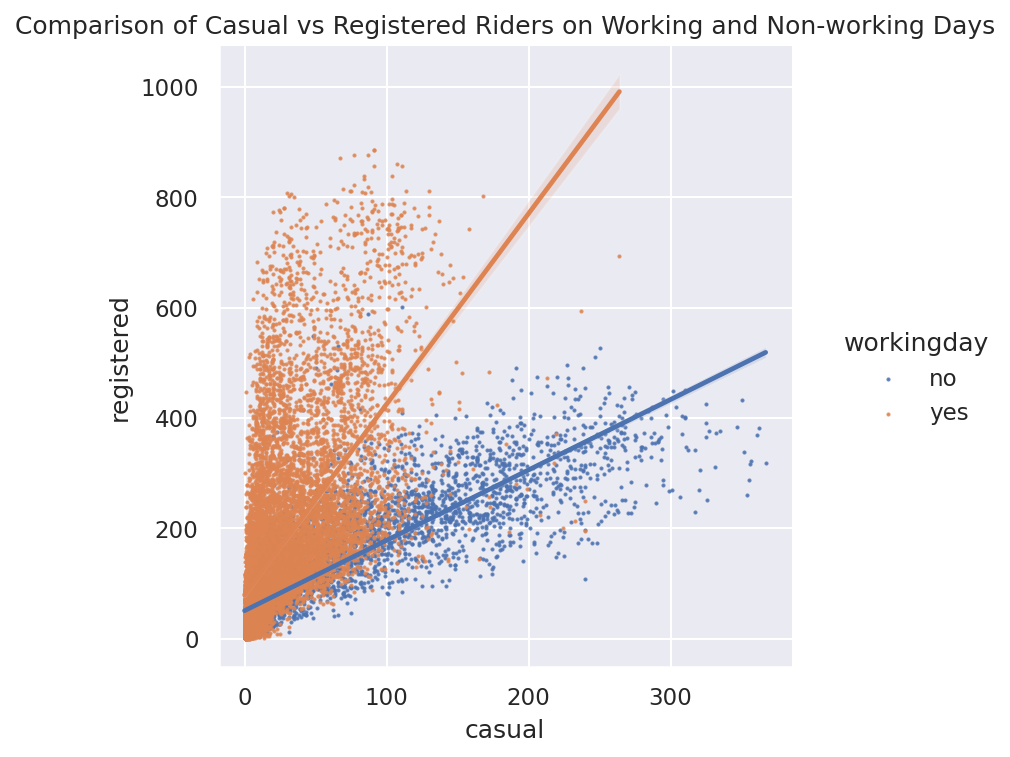

```python
# Make the font size a bit bigger
plt.figure(figsize=(12,10))
sns.set(font_scale=1)
sns.lmplot(data=bike, x='casual', y='registered', hue='workingday', fit_reg=True, scatter_kws={'s': 1})
plt.title("Comparison of Casual vs Registered Riders on Working and Non-working Days")
```

This helps us visualize that indeed casual riders are more prevalent on the non-working days whereas registered riders are prevalent on the working days.

## Visualization

#### Bivariate Kernel Density Plot

To address overplotting, I tried visualizing the data with another technique, the bivariate kernel density estimate.

A basic kde plot of all the data is quite easy to generate. However, this plot includes both weekend and weekday data, which isn't what I wanted...

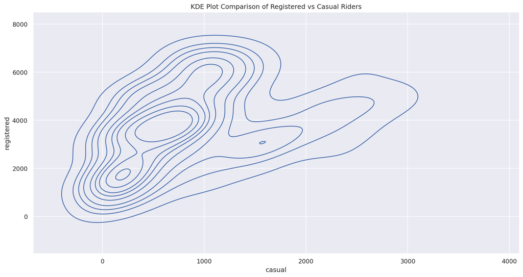

```python
sns.kdeplot(x=daily_counts['casual'], y=daily_counts['registered'])
plt.title('KDE Plot Comparison of Registered vs Casual Riders');
```

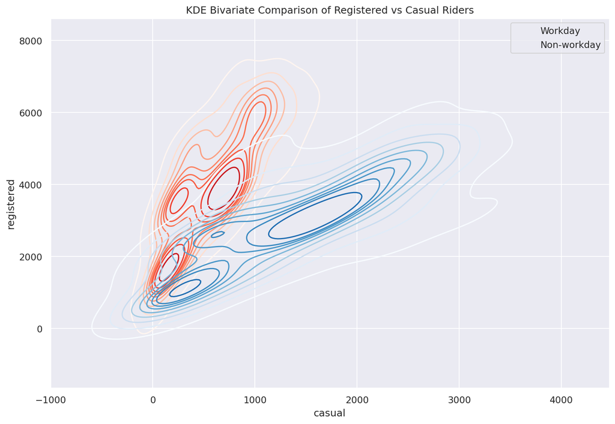

```python
# Set the figure size for the plot
plt.figure(figsize=(12,8))

# Set 'is_workingday' to a boolean array that is true for all working_days
is_workingday = daily_counts['workingday'] == "yes"

# Bivariate KDEs require two data inputs.
# In this case, we will need the daily counts for casual and registered riders on workdays
casual_workday = daily_counts.loc[is_workingday, 'casual']
registered_workday = daily_counts.loc[is_workingday, 'registered']

# Used sns.kdeplot on the two variables above to plot the bivariate KDE for weekday rides
sns.kdeplot(x=casual_workday, y=registered_workday, cmap='Reds', shade=False, shade_lowest=False, label='Workday')

not_workingday = daily_counts['workingday'] == "no"

# Repeat the same steps above but for rows corresponding to non-workingdays

casual_non_workday = daily_counts.loc[not_workingday, 'casual']
registered_non_workday = daily_counts.loc[not_workingday, 'registered']

# Used sns.kdeplot on the two variables above to plot the bivariate KDE for non-workingday rides
sns.kdeplot(x=casual_non_workday, y=registered_non_workday, cmap='Blues', shade=False, shade_lowest=False, label='Non-workday')

plt.title('KDE Bivariate Comparison of Registered vs Casual Riders');
plt.legend();
```

And Voilà! The lines from each color represent a group, where the shade of each group color represents the density. And the overlaping conglomerations between registered and casual users. The scatter plot made it seem as if there was almost not relationship between the groups.

## Joint Plot

As an alternative approach to visualizing the data, I constructed the following set of three plots where the main plot showed the contours of the kernel density estimate of daily counts for registered and casual riders plotted together, and the two "margin" plots (at the top and right of the figure) provided the univariate kernel density estimate of each of these variables.

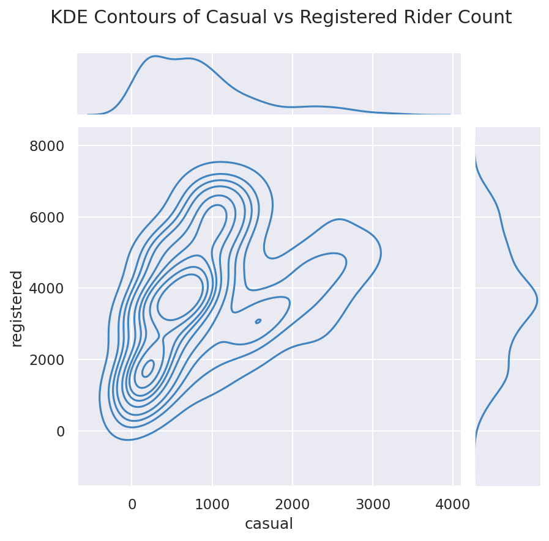

```python
sns.jointplot(data=daily_counts, x='casual', y='registered', kind='kde', color='#4184bf')
plt.suptitle("KDE Contours of Casual vs Registered Rider Count")
plt.subplots_adjust(top=0.9);
```

## Understanding Daily Patterns

I wanted to examine the behavior of riders by plotting the average number of riders for each hour of the day over the **entire dataset**, stratified by rider type.

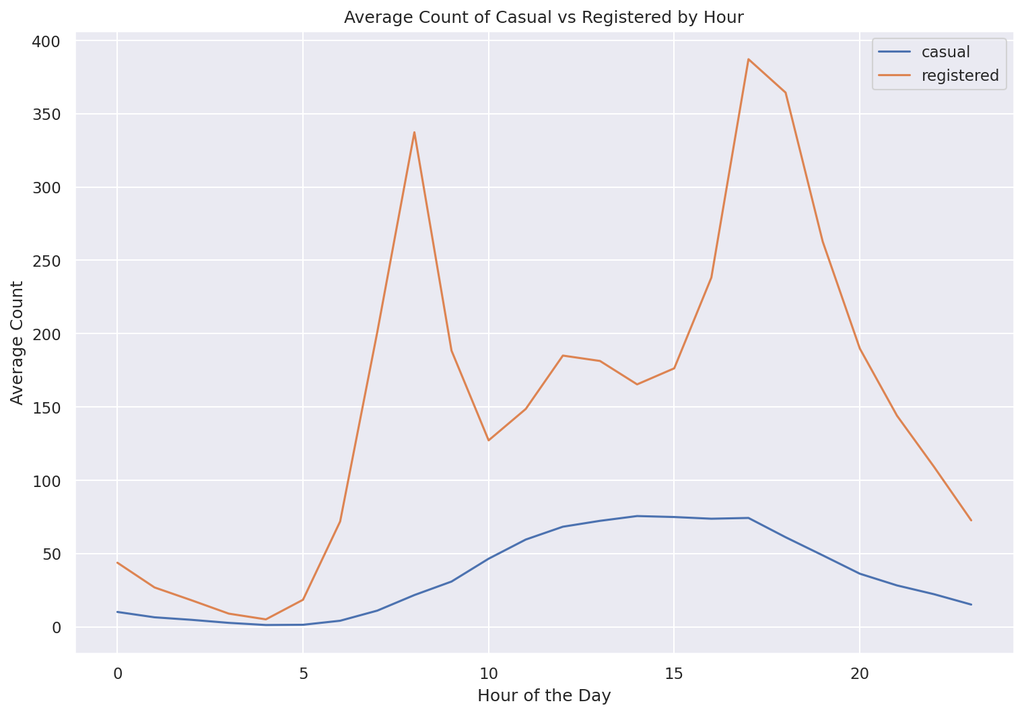

```python
plt.figure(figsize=(12,8))
plt.plot(bike.groupby('hr')['casual'].mean(), label='casual')
plt.plot(bike.groupby('hr')['registered'].mean(), label='registered')
plt.title('Average Count of Casual vs Registered by Hour')
plt.xlabel('Hour of the Day')
plt.ylabel('Average Count')
plt.legend();
```

We can observe that registered users tend to ride mostly to commute, in the mornings and evenings. Whereas Casual users ride more during the middle of the day.

## Exploring Ride Sharing and Weather

Then, I examined how the weather was affecting rider's behavior. First I looked at how the proportion of casual riders changes as weather changes.

I created a new column `prop_casual` in the `bike` DataFrame representing the proportion of casual riders out of all riders for each record.

```python
bike.head(1)
```

|  | instant | dteday | season | yr | mnth | hr | holiday | weekday | workingday | weathersit | temp | atemp | hum | windspeed | casual | registered | cnt |
| --- | --- | --- | --- | --- | --- | --- | --- | --- | --- | --- | --- | --- | --- | --- | --- | --- | --- |
| 0 | 1 | 2011-01-01 | 1 | 0 | 1 | 0 | no | Sat | no | Clear | 0.24 | 0.2879 | 0.81 | 0.0 | 3 | 13 | 16 |

```python
bike['prop_casual'] = bike['casual'] / (bike['casual'] + bike['registered'])
bike.head(1)
```

|  | instant | dteday | season | yr | mnth | hr | holiday | weekday | workingday | weathersit | temp | atemp | hum | windspeed | casual | registered | cnt | prop_casual |
| --- | --- | --- | --- | --- | --- | --- | --- | --- | --- | --- | --- | --- | --- | --- | --- | --- | --- | --- |
| 0 | 1 | 2011-01-01 | 1 | 0 | 1 | 0 | no | Sat | no | Clear | 0.24 | 0.2879 | 0.81 | 0.0 | 3 | 13 | 16 | 0.1875 |

#### Relationship

In order to examine the relationship between proportion of casual riders and temperature, I created a scatterplot using [`sns.scatterplot`](https://seaborn.pydata.org/generated/seaborn.scatterplot.html). I could even use color/hue to encode the information about day of week.

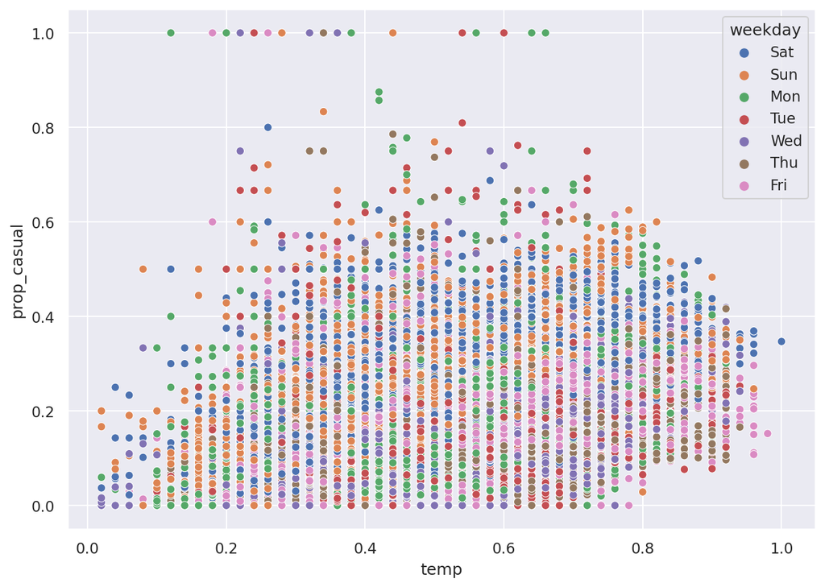

```python
plt.figure(figsize=(10, 7))
sns.scatterplot(data=bike, x="temp", y="prop_casual", hue="weekday");
```

I could attempt linear regression using `sns.lmplot` as shown below, which hint at some relationships between temperature and proportional casual, but the plot was still fairly unconvincing.

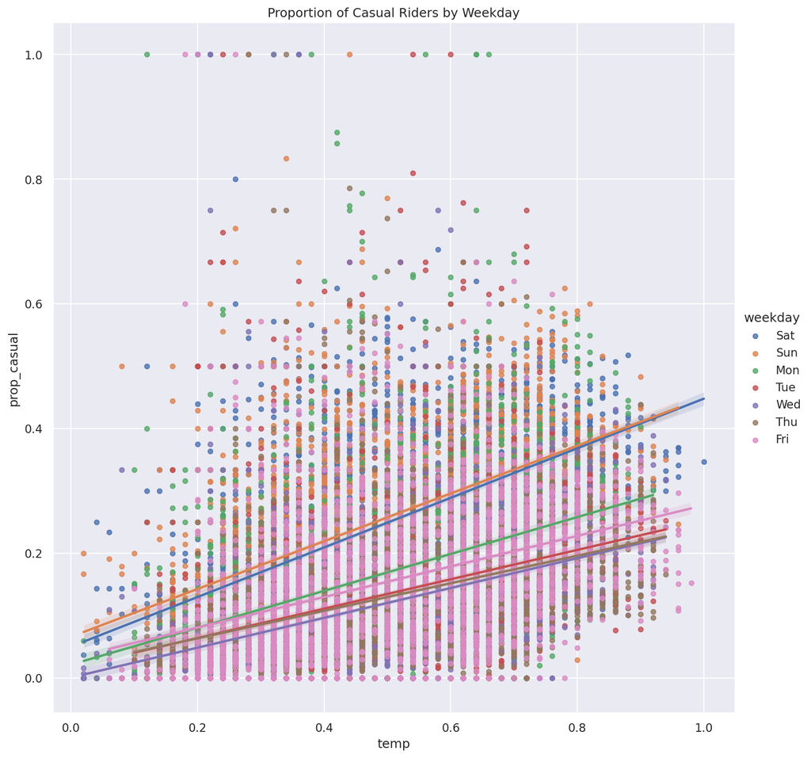

```python
sns.lmplot(data=bike, x="temp", y="prop_casual", hue="weekday", scatter_kws={"s": 20}, height=10)
plt.title("Proportion of Casual Riders by Weekday");
```

A better approach was to use local smoothing. The basic idea is that for each x value, I compute some sort of representative y value that captures the data close to that x value. One technique for local smoothing is "Locally Weighted Scatterplot Smoothing" or LOWESS. An example is below. The red curve shown is a smoothed version of the scatterplot.

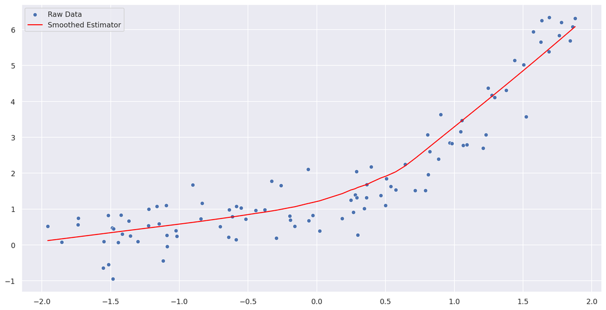

```python
from statsmodels.nonparametric.smoothers_lowess import lowess
# Make noisy data
xobs = np.sort(np.random.rand(100)*4.0 - 2)
yobs = np.exp(xobs) + np.random.randn(100) / 2.0
sns.scatterplot(xobs, yobs, label="Raw Data")

# Predict 'smoothed' valued for observations
ysmooth = lowess(yobs, xobs, return_sorted=False)
sns.lineplot(xobs, ysmooth, label="Smoothed Estimator", color='red')
plt.legend();
```

In this case with the bike ridership data, I wanted 7 curves, one for each day of the week. The x-axis as the temperature and the y-axis will as a smoothed version of the proportion of casual riders.

```python
bike["temp"].head(5)
```

```
0    0.24
1    0.22
2    0.22
3    0.24
4    0.24
Name: temp, dtype: float64
```

[figure not shown]

```python
from statsmodels.nonparametric.smoothers_lowess import lowess

plt.figure(figsize=(10,8))
for day in bike['weekday'].unique():
    day_df = bike[bike['weekday'] == day]
    y = day_df['prop_casual']
    x = day_df['temp'] * 100
    ysmooth = lowess(y, x, return_sorted=False)
    sns.lineplot(x, ysmooth, label=day)
plt.title('Temperature vs Casual Rider Proportion by weekday')
plt.xlabel('Temperature (Farhenheit)')
plt.ylabel('Casual Rider Proportion')
plt.legend();
```

## Expanding on the Analysis

I think the bike data could help us asses equity, although there is so much more that can be done as this dataset is pretty limited. We need to analyze the ridesharing dynamics across different neighborhoods with different demographics, we also could look at data from other cities and see what patterns do overlap across them. We could take a look at the race and gender of the registered users and also look what type of places do the users usually tend to go; commute? parks? groceries? -- There is so much that can still be done.

Now, [Bike sharing is growing in popularity](https://www.bts.gov/newsroom/bike-share-stations-us) and new cities and regions are making efforts to implement bike sharing systems that complement their other transportation offerings. The [goals of these efforts](https://www.wired.com/story/americans-falling-in-love-bike-share/) are to have bike sharing serve as an alternate form of transportation in order to alleviate congestion, provide geographic connectivity, reduce carbon emissions, and promote inclusion among communities.

Bike sharing systems have spread to many cities across the country. The company you work for asks you to determine the feasibility of expanding bike sharing to additional cities of the U.S.

Based on your plots in this project I would recommend to have bike stations available at the most dense workplaces. This could have now changed due to the pandemic and remote working, but in general the plots show that during the weekdays most users are riding for commuting, and one can assume to work.